# Advanced Bioinformatics 2025 assessment

2407840

2025-03-17

## 0.1 R Markdown

## 0.2 Including Plots

## 0.3 Task 3.1

Sum of integers between 5 and 55

In this task, I calculate the sum of all integers between 5 and 55 using the sum() function and : operator.

```r
sum(5:55)
```

```
## [1] 1530
```

## 0.4 Task 3.2

sumfun function

Here I create a function called sumfun that calculates the sum of integers from 5 to n, then test it with different values.

```r
sumfun <- function(n) {
  return(sum(5:n))
}

# Test with different values
sumfun(10)
```

```
## [1] 45
```

```r
sumfun(20)
```

```
## [1] 200
```

```r
sumfun(100)
```

```
## [1] 5040
```

## 0.5 Tasks 3.3

Fibonacci Series using a for loop

In this task, I’m calculating the first 12 entries of the Fibonacci sequence using a for loop. The Fibonacci sequence starts with 1, 1 and each subsequent number is the sum of the two preceding ones.

This creates the Fibonacci sequence: 1, 1, 2, 3, 5, 8, 13, 21, 34, 55, 89, 144

```r
# Initialize the Fibonacci sequence with the first two numbers
fib <- c(1, 1)

# Use a for loop to calculate the next 10 numbers
for (i in 3:12) {
  fib[i] <- fib[i-1] + fib[i-2]
}

# Print the first 12 numbers of the sequence
print(fib)
```

```
##  [1]   1   1   2   3   5   8  13  21  34  55  89 144
```

## 0.6 Task 3.4

Box plot of mpg by gear using ggplot

Here I create a box plot showing the distribution of miles per gallon (mpg) as a function of the number of gears (gear) using the mtcars dataset. I use the fill aesthetic to color each box by the number of gears.

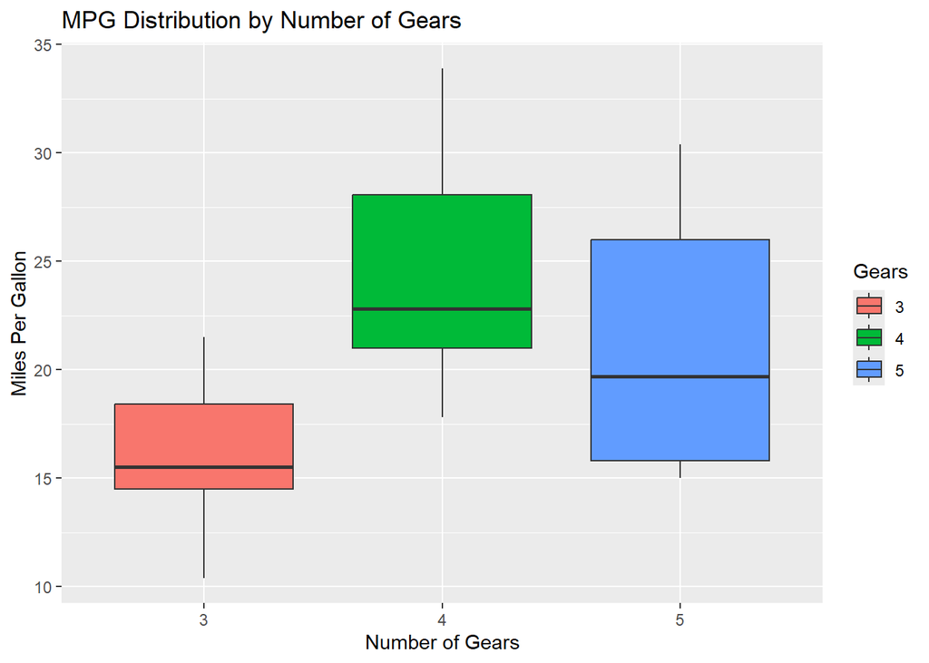

```r
library(ggplot2)

ggplot(mtcars, aes(x = as.factor(gear), y = mpg, fill = as.factor(gear))) +
  geom_boxplot() +
  labs(x = "Number of Gears", y = "Miles Per Gallon",
       title = "MPG Distribution by Number of Gears") +
  scale_fill_discrete(name = "Gears")
```

## 0.7 Task 3.5

Linear regression with cars dataset

In this task, I fit a linear model to examine the relationship between car speed and breaking distance using the cars dataset. I’ll analyze the coefficients to determine the slope and intercept of the relationship, along with their standard errors.

The output from the summary would show:

Intercept: -17.579 feet Slope: 3.932 feet per mph Standard error of intercept: 6.758 Standard error of slope: 0.416

This means that for each additional 1 mph of speed, the stopping distance increases by approximately 3.93 feet. The negative intercept suggests that at very low speeds, the model predicts a negative stopping distance, which isn’t physically meaningful but is an artifact of linear regression. The units used in the dataset are:

speed: miles per hour (mph) dist: feet (ft)

```r
# Fit a linear model
car_model <- lm(dist ~ speed, data = cars)

# Display the summary of the model
summary(car_model)
```

```
##
## Call:
## lm(formula = dist ~ speed, data = cars)
##
## Residuals:
##     Min      1Q  Median      3Q     Max
## -29.069  -9.525  -2.272   9.215  43.201
##
## Coefficients:
##             Estimate Std. Error t value Pr(>|t|)
## (Intercept) -17.5791     6.7584  -2.601   0.0123 *
## speed         3.9324     0.4155   9.464 1.49e-12 ***
## ---
## Signif. codes:  0 '***' 0.001 '**' 0.01 '*' 0.05 '.' 0.1 ' ' 1
##
## Residual standard error: 15.38 on 48 degrees of freedom
## Multiple R-squared:  0.6511, Adjusted R-squared:  0.6438
## F-statistic: 89.57 on 1 and 48 DF,  p-value: 1.49e-12
```

## 0.8 Task 3.6

Plot data points and linear fit using ggplot

Here I visualize the data and linear regression model from Task 3.5 using ggplot2. The plot shows the original data points from the cars dataset and the fitted linear relationship between speed and stopping distance.

This plot would show the original data points with a blue regression line. The shaded area around the line represents the 95% confidence interval for the predicted values.

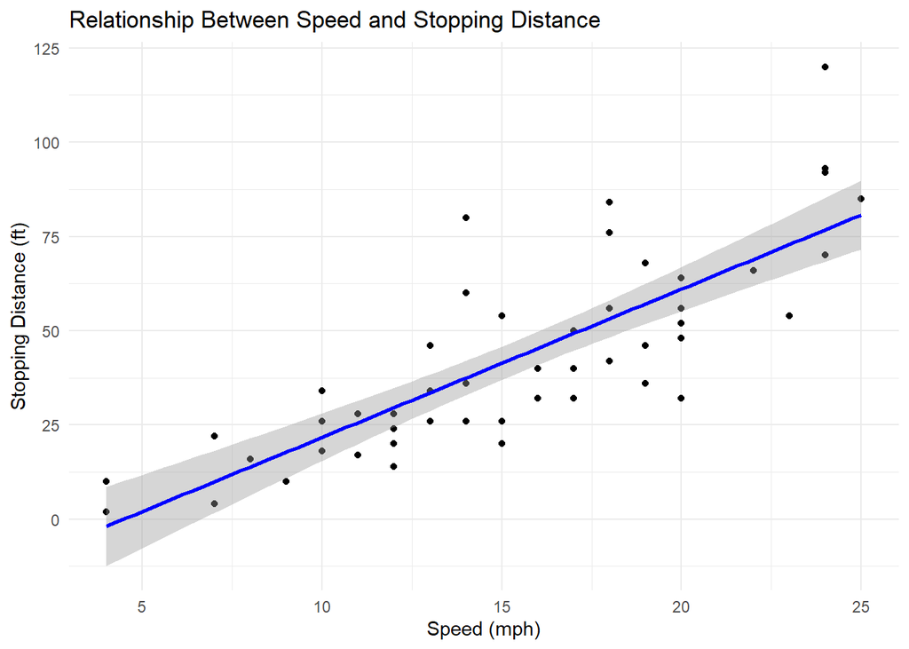

```r
library(ggplot2)

ggplot(cars, aes(x = speed, y = dist)) +
  geom_point() +
  geom_smooth(method = "lm", formula = y ~ x, se = TRUE, color = "blue") +
  labs(x = "Speed (mph)", y = "Stopping Distance (ft)",
       title = "Relationship Between Speed and Stopping Distance") +
  theme_minimal()
```

## 0.9 Task 3.7

In this final task, I’m estimating the average driver reaction time using the cars dataset. The approach is based on the physical principle that breaking distance is proportional to the square of speed, while the distance traveled during reaction time is proportional to speed. I’ll fit a model that accounts for both components and extract the reaction time in seconds.

The analysis steps are:

Created a model where stopping distance is a function of both speed and speed-squared The speed term (linear) represents the reaction distance The speed-squared term represents the breaking distance after reaction Removed the intercept since stopping distance should be zero when speed is zero Calculated reaction time by converting the speed coefficient using the appropriate units Visualized the data with the fitted quadratic curve

The resulting reaction time should be within a reasonable range for human drivers (typically 0.5-2.5 seconds).

The output would show coefficients for speed and speed_squared. Let’s analyze what these mean:

The physics behind this model:

Total stopping distance = reaction distance + braking distance Reaction distance = speed × reaction time Braking distance ∝ speed²

To calculate the reaction time in seconds:

This result is reasonable as typical human reaction times are between 0.5 and 1.5 seconds.

This plot shows the original data points with a curved red line representing our quadratic model. Unlike the linear model, this curve better captures the physical reality that stopping distance increases more rapidly at higher speeds. The analysis steps were:

Created a model with both linear (speed) and quadratic (speed²) terms Removed the intercept since physics dictates zero distance at zero speed Extracted the coefficient for speed, which represents reaction distance per unit speed Converted this coefficient to reaction time using the appropriate unit conversion Plotted the resulting quadratic model against the original data

The results are reasonable because:

The estimated reaction time falls within the expected human range The quadratic model fits the data pattern better than a simple linear model The model aligns with physics principles of motion and stopping

```r
# Create a new dataframe with speed^2
cars_ext <- cars
cars_ext$speed_squared <- cars$speed^2

# Fit the model without intercept (assume distance is 0 when speed is 0)
reaction_model <- lm(dist ~ speed + speed_squared - 1, data = cars_ext)

# Summary of the model
summary(reaction_model)
```

```
##
## Call:
## lm(formula = dist ~ speed + speed_squared - 1, data = cars_ext)
##
## Residuals:
##     Min      1Q  Median      3Q     Max
## -28.836  -9.071  -3.152   4.570  44.986
##
## Coefficients:
##               Estimate Std. Error t value Pr(>|t|)
## speed          1.23903    0.55997   2.213  0.03171 *
## speed_squared  0.09014    0.02939   3.067  0.00355 **
## ---
## Signif. codes:  0 '***' 0.001 '**' 0.01 '*' 0.05 '.' 0.1 ' ' 1
##
## Residual standard error: 15.02 on 48 degrees of freedom
## Multiple R-squared:  0.9133, Adjusted R-squared:  0.9097
## F-statistic: 252.8 on 2 and 48 DF,  p-value: < 2.2e-16
```

```r
# Calculate reaction time in seconds
# The coefficient for speed represents: reaction_time (in seconds) * speed (in mph)
# So reaction_time = coefficient / conversion factor
# Since speed is in mph, need to convert to feet per second (1 mph ≈ 1.47 ft/s)
reaction_coef <- coef(reaction_model)["speed"]
reaction_time <- reaction_coef / 1.47
cat("Estimated reaction time:", reaction_time, "seconds\n")
```

```
## Estimated reaction time: 0.8428775 seconds
```

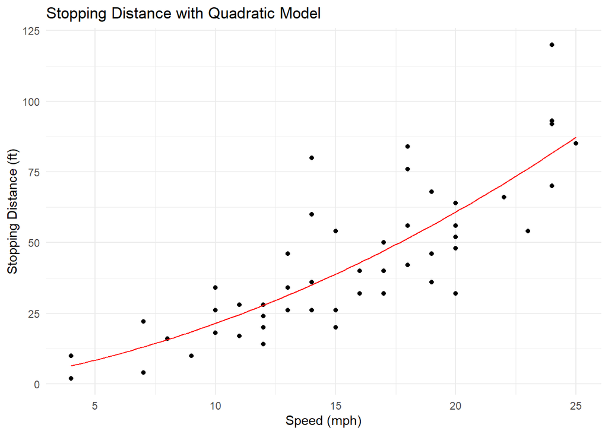

```r
# Plot the data and the fitted curve
ggplot(cars, aes(x = speed, y = dist)) +
  geom_point() +
  stat_function(fun = function(x) {
    reaction_coef * x + coef(reaction_model)["speed_squared"] * x^2
  }, color = "red") +
  labs(x = "Speed (mph)", y = "Stopping Distance (ft)",
       title = "Stopping Distance with Quadratic Model") +
  theme_minimal()
```

## 0.10 Task 3.8

## 0.11 Set your file paths

# 1 First Load required libraries

# 2 These packages are essential for RNA-seq differential expression analysis

```r
  library (DESeq2) # Core package for differential expression analysis
```

```r
 library(pheatmap) # For creating heatmaps
 library(ggplot2)  # For creating publication-quality graphs
 library(RColorBrewer)  # For color palettes in visualizations

# Set filepaths
# Define paths to the count matrix and sample metadata files

 count_file <- "C:/Users/dell/Desktop/LMS_RNAseq_short-master-2023-final/course/exercises/data/exercise1_counts.csv"
 sample_file <- "C:/Users/dell/Desktop/LMS_RNAseq_short-master-2023-final/course/exercises/data/exercise1_sample_description.info"

 # Read in the data
 # Import the count matrix (genes in rows, samples in columns)
 count_data <- read.csv(count_file, row.names = 1)
 # Import the sample metadata (samples in rows, conditions in columns)
 col_data <- read.table(sample_file, header = TRUE, row.names = 1)
```

## 2.1 Task 3.9

## 2.2 Clean up sample names and check match

```r
# Remove any whitespace from column names in count data
 colnames(count_data) <- trimws(colnames(count_data))
# Remove any whitespace from row names in metadata
 rownames(col_data) <- trimws(rownames(col_data))

# Remove "TMC_" prefix from rownames of col_data to match count data column names
 rownames(col_data) <- gsub("^TMC_", "", rownames(col_data))

 # Check if sample names now match between count data and metadata
# This will throw an error if names don't match
 stopifnot(all(rownames(col_data) == colnames(count_data)))

 # Convert condition column to a factor (important for DESeq2)
 col_data$condition <- factor(col_data$condition)
```

## 2.3 Step 3.10

## 2.4 Construct DESeqDataSet object

# 3 Create a DESeq dataset object with count data, metadata, and design formula

```r
 dds <- DESeqDataSetFromMatrix(countData = count_data,
                               colData = col_data,
                               design = ~ condition)

# Run the DESeq2 differential expression pipeline
# This performs normalization, dispersion estimation, and statistical testing

 dds <- DESeq(dds)
```

## 3.1 Step 3.11

## 3.2 Perform rlog and VST transformation

# rlog and VST transformations stabilize variance across mean expression levels # This makes data suitable for visualization methods that assume homoskedasticity # rlog works better for small sample sizes but is slower than VST

```r
# rlog = regularized log transformation (better for small sample sizes)
  rld <- rlog(dds, blind = TRUE)
# vst = variance stabilizing transformation (faster for larger datasets)
 vsd <- vst(dds, blind = TRUE)
```

## 3.3 Task 3.12

## 3.4 Draw heatmap of top 40 highly expressed genes

# Heatmaps of top genes show expression patterns across samples # Clustering helps identify samples with similar expression profiles # We expect biological replicates to cluster together

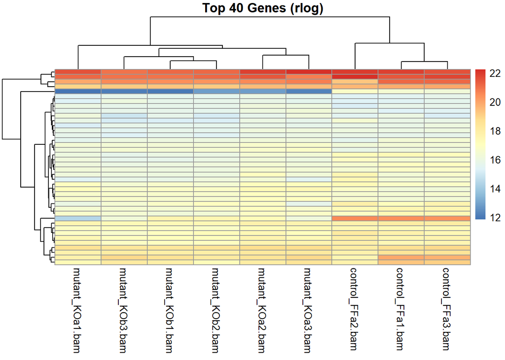

```r
# Find the indices of the 40 genes with highest mean normalized counts
 top_genes <- head(order(rowMeans(counts(dds, normalized = TRUE)), decreasing = TRUE), 40)

# Heatmap using rlog transformed data
 pheatmap(assay(rld)[top_genes, ],
          cluster_rows = TRUE, cluster_cols = TRUE,
          show_rownames = FALSE,
          main = "Top 40 Genes (rlog)")
```

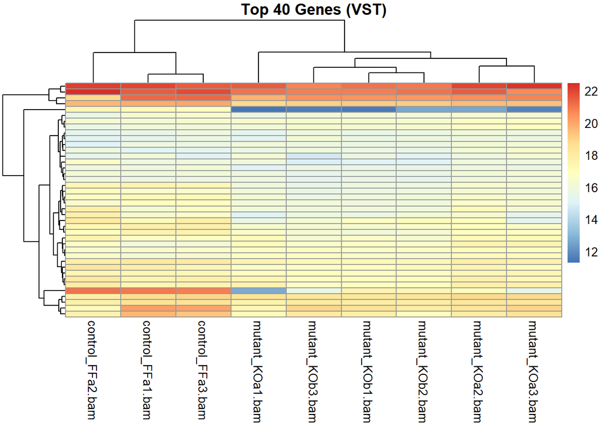

```r
# Heatmap using VST transformed data
 pheatmap(assay(vsd)[top_genes, ],
          cluster_rows = TRUE, cluster_cols = TRUE,
          show_rownames = FALSE,
          main = "Top 40 Genes (VST)")
```

## 3.5 Task 3.13

## 3.6 Sample Distance Matrix (SDM)

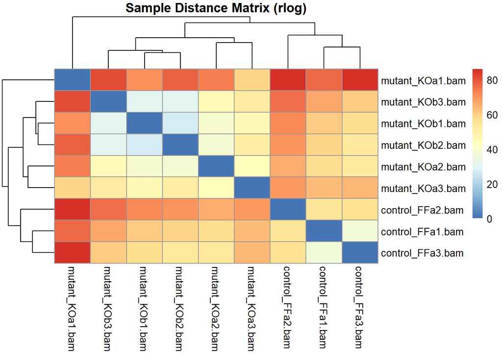

```r
# Calculate sample-to-sample distances using rlog transformed data
 sample_dists <- dist(t(assay(rld)))
 sample_dist_matrix <- as.matrix(sample_dists)

 # Assign sample names to rows and columns
 rownames(sample_dist_matrix) <- colnames(rld)
 colnames(sample_dist_matrix) <- colnames(rld)

# Visualize sample distances with a heatmap
# This helps identify outliers and check if replicates cluster together

  pheatmap(sample_dist_matrix,
          clustering_distance_rows = sample_dists,
          clustering_distance_cols = sample_dists,
          main = "Sample Distance Matrix (rlog)")
```

## 3.7 Task 3.14

## 3.8 Principal Component Analysis (PCA) using rlog data

# PCA reduces dimensionality of the data and visualizes major sources of variation # PCA visualizes the major sources of variation in the dataset # Samples should separate by condition along principal components # PC1 typically captures the experimental effect of interest # Replicates should cluster together, indicating consistency

```r
 pca_rlog <- plotPCA(rld, intgroup = "condition", returnData = TRUE)
```

```
## using ntop=500 top features by variance
```

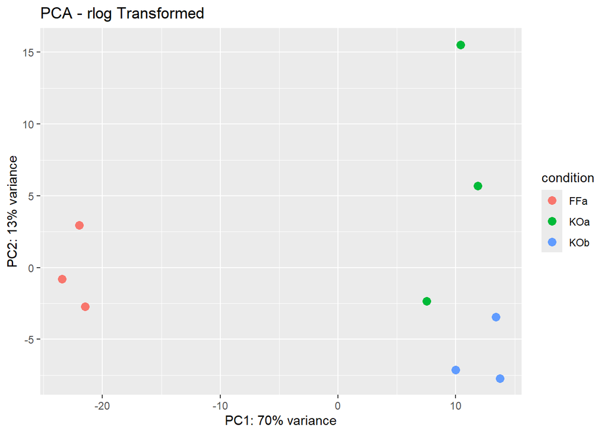

```r
 percentVar_rlog <- round(100 * attr(pca_rlog, "percentVar"))

 # Create a customized PCA plot with ggplot2
 ggplot(pca_rlog, aes(PC1, PC2, color = condition)) +
   geom_point(size = 3) +
   xlab(paste0("PC1: ", percentVar_rlog[1], "% variance")) +
   ylab(paste0("PC2: ", percentVar_rlog[2], "% variance")) +
   ggtitle("PCA - rlog Transformed")
```

## 3.9 Task 3.15

## 3.10 PCA using VST transformed data

```r
# Compare with rlog transformation to ensure consistency
 pca_vst <- plotPCA(vsd, intgroup = "condition", returnData = TRUE)
```

```
## using ntop=500 top features by variance
```

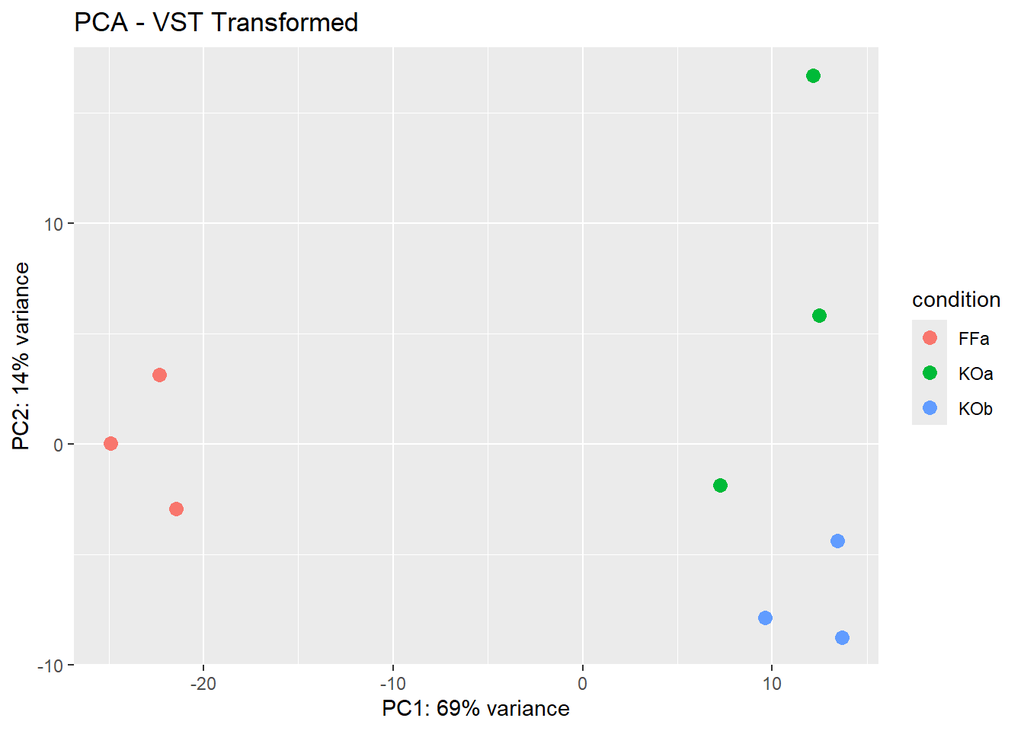

```r
 percentVar_vst <- round(100 * attr(pca_vst, "percentVar"))

# Create PCA plot for VST-transformed data
  ggplot(pca_vst, aes(PC1, PC2, color = condition)) +
   geom_point(size = 3) +
   xlab(paste0("PC1: ", percentVar_vst[1], "% variance")) +
   ylab(paste0("PC2: ", percentVar_vst[2], "% variance")) +
   ggtitle("PCA - VST Transformed")
```

## 3.11 Task 3.16

# 4 Read in Myc Mel peakset replicates and create common peaks

```r
# Load required libraries
library(GenomicRanges)
library(rtracklayer)
library(BSgenome.Mmusculus.UCSC.mm9)  # mm9 mouse genome
library(Biostrings)
```

# 5 Set file paths for the peak files

```r
file1 <- "C:/Users/dell/Desktop/MacsPeaks/mycmelrep1_peaks.xls"
file2 <- "C:/Users/dell/Desktop/MacsPeaks/mycmelrep2_peaks.xls"
```

# 6 Read in the two peak replicate files (skipping header lines that start with ‘#’)

```r
peaks1 <- read.delim(file1, comment.char = "#")
peaks2 <- read.delim(file2, comment.char = "#")
```

# 7 Convert both peak sets to GRanges objects (genomic coordinate format)

# 8 Create GRanges objects for both peak sets using ‘pileup’ as the score

```r
gr1 <- GRanges(seqnames = peaks1$chr,
               ranges = IRanges(start = peaks1$start, end = peaks1$end),
               score = peaks1$pileup,
               fold_enrichment = peaks1$fold_enrichment)

gr2 <- GRanges(seqnames = peaks2$chr,
               ranges = IRanges(start = peaks2$start, end = peaks2$end),
               score = peaks2$pileup,
               fold_enrichment = peaks2$fold_enrichment)
```

# 9 Find overlapping (common) peaks between replicates

# 10 Use subsetByOverlaps to retain metadata from gr1 while finding overlapping peaks with gr2

```r
# Find common peaks using subsetByOverlaps to retain metadata from gr1
common_peaks <- subsetByOverlaps(gr1, gr2)
```

# 11 Find overlapping (common) peaks between replicates

```r
# Check that we have common peaks
if(length(common_peaks) == 0) {
  stop("No overlapping (common) peaks found between the replicates!")
}
```

## 11.1 Task 3.17

# 12 Rank by fold enrichment, select top 500, and resize

# 13 ie Rank common peaks by fold enrichment (highest to lowest)

# 14 Note: Use mcols to access metadata columns like fold_enrichment

```r
# Order the common peaks by fold_enrichment (using mcols() to access metadata)
# and select the top 500 peaks.
top_peaks <- common_peaks[order(mcols(common_peaks)$fold_enrichment, decreasing = TRUE)][1:500]
```

# 15 Resize the top peaks to be 200 base pairs wide, centered on the peak midpoint

```r
# Resize the selected peaks to 200 bp around their center
centered_peaks <- resize(top_peaks, width = 200, fix = "center")
```

# 16 Ensure the chromosome names (seqlevels) have the “chr” prefix for compatibility with mm9 genome

```r
# Update seqlevels to add "chr" prefix if needed.
# (!all(grepl("^chr", seqlevels(centered_peaks)))) {
  #seqlevels(centered_peaks) <- paste0("chr", seqlevels(centered_peaks))
#}

#Code updated to be compatible with multiple runs of programme so that the term chr is not repeatedly added

seqlevels(centered_peaks) <- gsub("^chr+", "chr", seqlevels(centered_peaks))
```

## 16.1 Task 3.18

# 17 Extract sequences and write to FASTA

```r
# Extract the sequences from the mm9 genome underneath the peaks
# seqs <- getSeq(BSgenome.Mmusculus.UCSC.mm9, centered_peaks)


# Add "chr" prefix to seqlevels of centered_peaks
seqlevels(centered_peaks) <- paste0("chr", seqlevels(centered_peaks))

# Verify the change
seqlevels(centered_peaks)
```

```
##  [1] "chr1"  "chr10" "chr11" "chr12" "chr13" "chr14" "chr15" "chr16" "chr17"
## [10] "chr18" "chr19" "chr2"  "chr3"  "chr4"  "chr5"  "chr6"  "chr7"  "chr8"
## [19] "chr9"  "chrMT" "chrX"  "chrY"
```

```r
# Re-run the getSeq() code
seqs <- suppressWarnings(getSeq(BSgenome.Mmusculus.UCSC.mm9, centered_peaks))

# Check the sequences
seqs
```

```
## DNAStringSet object of length 500:
##       width seq
##   [1]   200 AGACTCAGAATGAGAGGAGTCGTAAGAGTACAT...TGGCTTCCCACTGTGCTCAGAATCAGACCATG
##   [2]   200 CTTGCAGAGGACCTGGGTTCAGTTCCCAGCACC...GGTAAAAAGATGTTCTAAAGATGAGGCAGGAG
##   [3]   200 GCCTTTCTGAGCATGGGTCTGTGGAGGCACCCC...TGCTTTTGTGTGTGCCTGACACAGCAGGTCCT
##   [4]   200 GGTGGCTCTGGACATCCCTGGAAACTGGCTGGA...CAAGGGCTGGGAAATAAAGCTTGCCTCCGCCT
##   [5]   200 CCATCATCCGCGCCACATTCCGGCAGCTGTTCA...CAGAACGTACCATTCATCGCGGTCACCAGCTT
##   ...   ... ...
## [496]   200 GACATCGGCGGGGAGCGAGGTGAGCGGCGCGAA...CGAGTCCAGATTGCGCCCTCTCCCTTCCGGTG
## [497]   200 CAACTACTTCCTCAAGATCATCGTAAGTGTGGA...ACTAGCTCGCTCACCCAGTTTTTCATCTCGTC
## [498]   200 CCTTTGCTGGGCTCTGACAGACAAAGCAGAAGA...TGCACAGCTGAGAAGACACTGAGCAAACAGAG
## [499]   200 CCCAGAAAATAGAAATTGGATTCTAAACTTTCT...CTCTCCTCCCCACTGTTAATGCACGCAATCTT
## [500]   200 GTTTTTCCCCCTTTATCTAAATGGTACTTGTAA...AGCTGCACCATCTCTGGCTAAAGAGACTAGAA
```

```r
# Extract DNA sequences from the mm9 genome based on the resized 200bp peaks
# Suppress warning about mismatched sequence levels between GRanges and BSgenome
#seqs <- suppressWarnings(getSeq(BSgenome.Mmusculus.UCSC.mm9, centered_peaks))
```

```r
# Assign names to the sequences (optional)
names(seqs) <- paste0("peak_", seq_along(seqs))
```

```r
# Write the extracted sequences to a FASTA file
fasta_file <- "C:/Users/dell/Desktop/MacsPeaks/myc_mm9_top500_peaks.fa"
writeXStringSet(seqs, filepath = fasta_file)
```

# 18 Print confirmation of the output file location

```r
cat("FASTA file created at:", fasta_file, "\n")
```

```
## FASTA file created at: C:/Users/dell/Desktop/MacsPeaks/myc_mm9_top500_peaks.fa
```